# Polyphénol - part 3: intégration des résultats

# 1/ Introduction

Ce fichier tente de faire le lien entre les différents résultats trouvés dans les analyses précédentes: - QTL de résistance - QTLs de métabolomique - Gènes différentiellement exprimés

Chargement des librairies

```r
library(xtable)
library(tidyverse)
library(gdata)
library(RColorBrewer)
library(d3heatmap)
```

Chargement des fichiers nécessaires

```r
# Génotypes aux QTLs
geno = read.table(file="~/Dropbox/Publi_Fusariose/ANALYSIS_REPRO/DATA/fichier_genotypage_QTL.csv", sep = ";" , header = F, na.strings = "-")
geno= as.matrix(geno)
colnames(geno)= geno[1,]
geno= as.data.frame(geno[-1 , ])
# keep interesting markers only
geno=geno[ , which(colnames(geno) %in% c("SNP","Traes_1BS_4073CE3DB@1683", "Traes_1BS_B9CBEFAE5@1271","Traes_5AL_99116D900@696"))]
colnames(geno)[1]="geno"

# Données des composés phénoliques 2013
metabo=read.xls("../../DATA/PHENOTYPE/Metabolomique_Data.xlsx", sheet = 1, header = TRUE)
metabo=metabo[,-1]
metabo$geno=gsub("DC","DC.",metabo$geno)

# QTLs des données de métabo
QTL_metabo=read.table(file="../../../SUPPORTING_DATA/OR_detail_all_QTLs_metabo.csv", header=T, sep=";")
```

# 2/ Description Données Métabo

Voici le nombre de composés dans chaque catégorie:

```r
nature=rep(NA, ncol(metabo))
nature[grep("_280", colnames(metabo))]="g280"
nature[grep("_320", colnames(metabo))]="g320"
nature[grep("_360", colnames(metabo))]="g360"
nature[is.na(nature)]="gKnown"
table(nature)
```

```
## nature
##   g280   g320   g360 gKnown
##      9      9     35      6
```

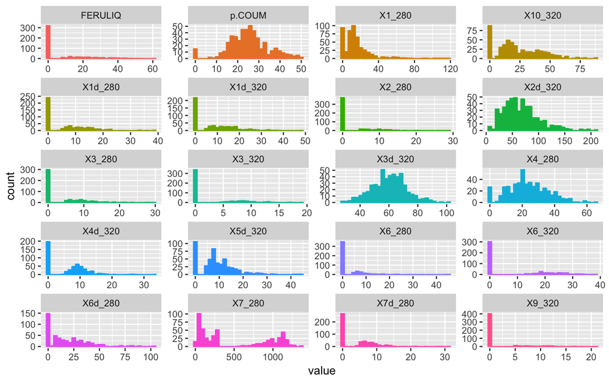

```r
metabo %>%
  select(1:21) %>%
  gather(compose, value, 2:21) %>%
  ggplot(aes(x=value, color=compose, fill=compose)) +
    geom_histogram() +
    #geom_vline( xintercept=mean(metabo$value, na.rm=T), color="red", size=1) +
    facet_wrap(~compose, scales = "free", ncol=4) +
    theme(legend.position="none")
```

# 3/ Heatmap

Création d’une matrice moyennée. On obtient une ligne par génotype

```r
metabomoy=metabo %>%
  group_by(geno) %>%
  summarise_each(funs(mean))
metabomoy=data.frame(metabomoy)
rownames(metabomoy)=metabomoy$geno
metabomoy=metabomoy[,-1]
```

On peut ensuite normaliser cette matrice

```r
# Matrice normalisée par colonne:
#metabomoynorm=scale(as.matrix(metabomoy))

# Matrice normalisée par ligne:
#metabomoynorm=t(scale(t(as.matrix(metabomoy))))

# Matrice normalisée par ligne et colonne
metabomoynorm=scale(as.matrix(metabomoy))
metabomoynorm=t(scale(t(metabomoynorm)))
```

Création d’un vecteur de couleur pour la famille de composé

```r
# compo vector
famille=as.numeric(as.factor(nature))[-1]
famille=brewer.pal(4, "Set1")[famille]
```

Création d’un vecteur de couleur: ai-je un QTL pour ce composé?

```r
with_QTL=QTL_metabo %>% filter(chromo=="1B") %>% select(carac) %>%  mutate(carac = gsub("_blup13","",carac))
QTL=as.numeric(colnames(metabo) %in% with_QTL[,1])[-1] +1
QTL=brewer.pal(2, "Set1")[QTL]
```

Création d’un vecteur de couleur en fonction de l’allèle de l’individu aux QTLs 1B et 5A! On en profite pour rappeler les effectif de chaque classe.

```r
# effectif:
table(geno[,c(2,4)])
```

```
##                         Traes_5AL_99116D900@696
## Traes_1BS_B9CBEFAE5@1271  A  B
##                        A 48 30
##                        B 45 25
```

```r
# allele vector for both QTL
#tmp=geno[match( rownames(metabomoynorm) , geno$geno) , ]
#allele=as.numeric(as.factor(as.character(paste(tmp$`Traes_1BS_B9CBEFAE5@1271`, tmp$`Traes_5AL_99116D900@696`, sep="-"))))
#allele=brewer.pal(nlevels(as.factor(allele)), "Set2")[allele]
# allele vector for QTL 1B
tmp=geno[match( rownames(metabomoynorm) , geno$geno) , ]
allele=as.numeric(as.factor(tmp$`Traes_1BS_B9CBEFAE5@1271`))
allele=brewer.pal(nlevels(as.factor(allele)), "Set1")[allele]
# allele vector for QTL 5A
#tmp=geno[match( rownames(metabomoynorm) , geno$geno) , ]
#allele=as.numeric(as.factor(tmp$`Traes_5AL_99116D900@696`))
#allele=brewer.pal(nlevels(as.factor(allele)), "Set2")[allele]
```

Créationd du heatmap

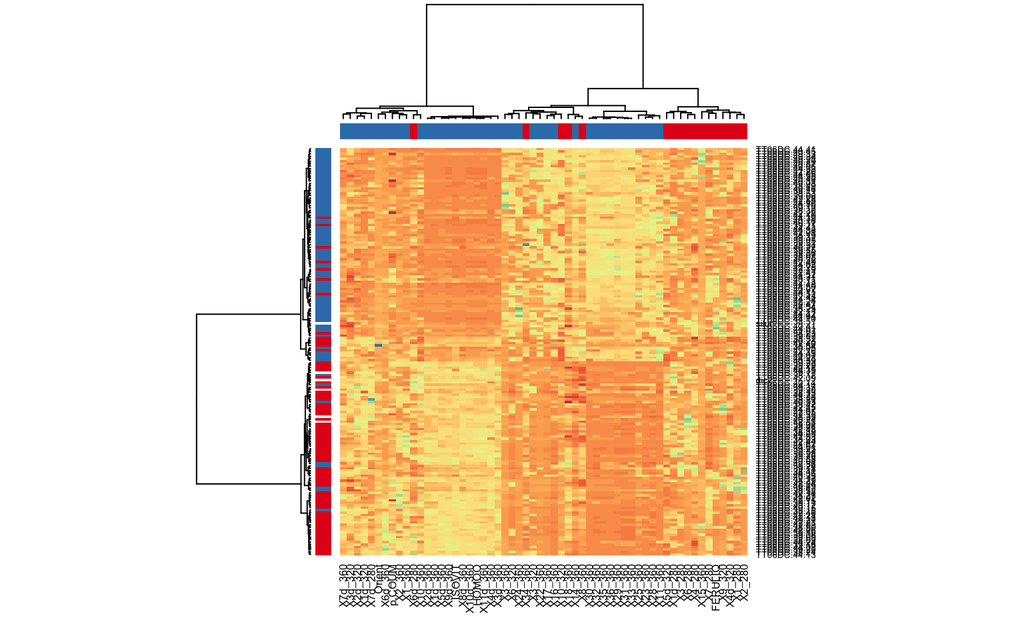

```r
#, fig.width=6, fig.height=9}

# fonction de distance
distance <- function(x) as.dist(1-cor(t(x)))
#distance <- function(x) dist(x)

# Fonction de clusterisation
hclust.ave <- function(x) hclust(x, method="ward.D")

# color palette
coul = colorRampPalette(brewer.pal(8, "Spectral"))(33)

# heatmap
heatmap(as.matrix(metabomoynorm),
        scale="none" ,
        distfun=distance,
        hclustfun=hclust.ave,
        ColSideColors=QTL,
        RowSideColors=allele,
        col = coul
        )
```

# 4/ Heatmap format 1 - 0

On peut donc faire une matrice de 0 et de 1: j’ai ou je n’ai pas le composé!

```r
metabo01=metabo %>%
  group_by(geno) %>%
  summarise_each(funs(mean)) %>%
  mutate_each(funs(ifelse(.>mean(.),1,0) ), -geno)
```

Visualisation de cette matrice sous forme de heatmap. Chaque ligne représente un individu, et la couleur associée représente l’allèle au QTL 1B. Chaque colonne représente un composé, et la couleur associée représente le groupe du composé (360, 280…). Chaque carré permet donc de savoir si le composé est présent chez l’individu.(Rouge ou Jaune)

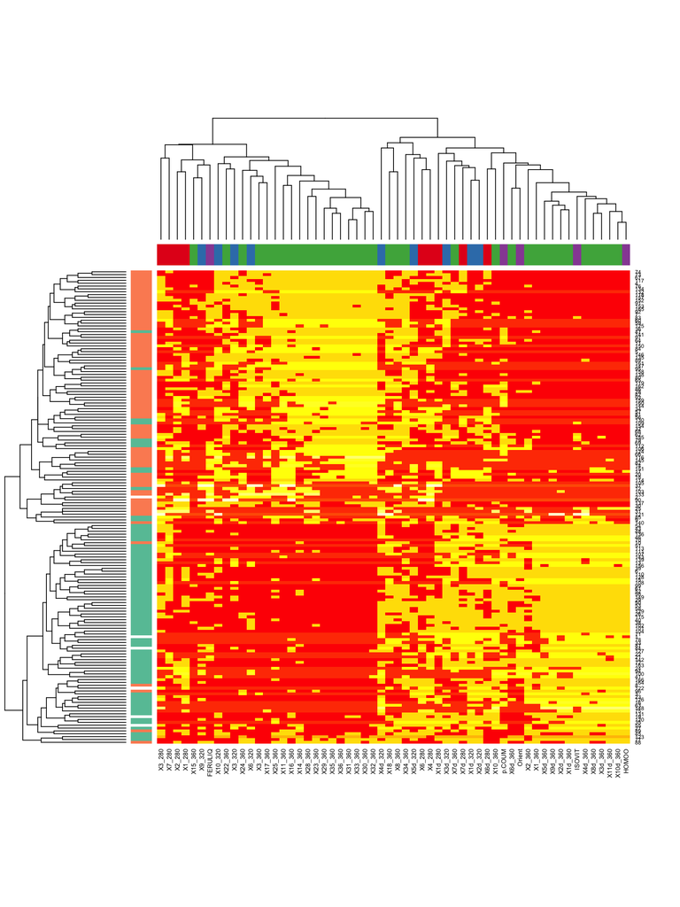

```r
# compo vector
compo=as.numeric(as.factor(nature))[-1]
compo=brewer.pal(4, "Set1")[compo]

# allele vector
tmp=geno[match( metabo01$geno , geno$geno) , ]
allele=as.numeric(as.factor(tmp$"Traes_1BS_B9CBEFAE5@1271"))
allele=brewer.pal(2, "Set2")[allele]

# heatmap
metabo01 %>%
  select(-geno) %>%
  as.matrix() %>%
  heatmap(ColSideColors=compo, RowSideColors=allele, method="ward.D")
```

Idem en interactif pour avoir plus de détail

```r
# heatmap
metabo01 %>%
  select(-geno) %>%
  as.matrix() %>%
  d3heatmap(colors = "Spectral", labRow=metabo01$geno, k_row=2, k_col=2)
```

[interactive chart not shown]

On observe 2 groupes très distincts. Le premier groupe possède l’allèle A au QTL et exprime une moitié des composés et pas l’autre. Le deuxième groupe possède l’allèle B et exprime l’autre moitié des composés. Cependant, on a pas de classement claire des groupes de composés.

# Clusterisation?

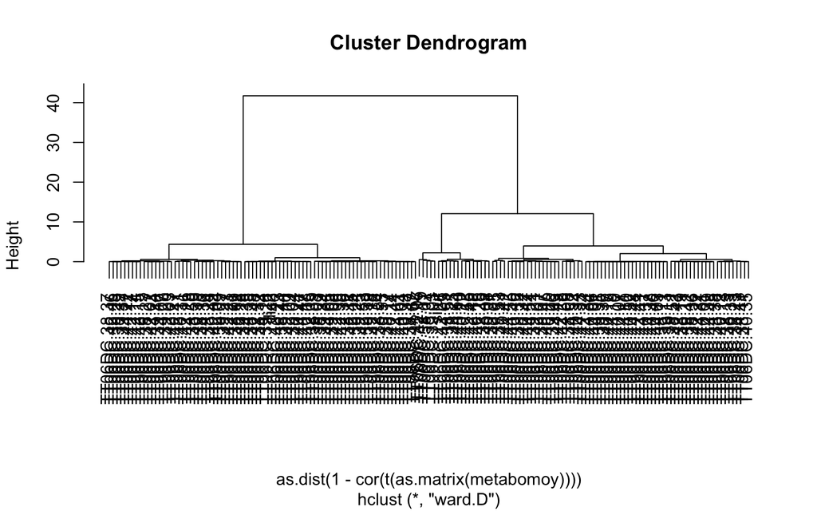

```r
a=hclust(as.dist(1-cor(t(as.matrix(metabomoy)))), method="ward.D")
plot(a)
```

```r
cutree(a, k=2)
```

```
##         dic2        silur TT06DC.38.03 TT06DC.38.07 TT06DC.38.08
##            1            2            1            2            2
## TT06DC.38.09 TT06DC.38.11 TT06DC.38.12 TT06DC.38.13 TT06DC.38.15
##            1            2            1            2            1
## TT06DC.38.19 TT06DC.38.23 TT06DC.38.24 TT06DC.38.25 TT06DC.38.27
##            2            2            1            2            1
## TT06DC.38.29 TT06DC.38.32 TT06DC.38.34 TT06DC.38.35 TT06DC.38.36
##            1            1            2            1            2
## TT06DC.38.37 TT06DC.38.38 TT06DC.38.39 TT06DC.38.41 TT06DC.38.42
##            1            2            1            2            2
## TT06DC.38.44 TT06DC.38.47 TT06DC.38.49 TT06DC.38.50 TT06DC.38.51
##            1            1            2            1            2
## TT06DC.38.52 TT06DC.38.53 TT06DC.38.54 TT06DC.39.03 TT06DC.39.04
##            2            2            1            2            1
## TT06DC.39.06 TT06DC.39.07 TT06DC.39.08 TT06DC.39.09 TT06DC.39.10
##            2            2            1            1            1
## TT06DC.39.11 TT06DC.39.13 TT06DC.39.16 TT06DC.39.17 TT06DC.39.18
##            2            2            1            1            1
## TT06DC.39.20 TT06DC.39.21 TT06DC.39.23 TT06DC.39.24 TT06DC.39.25
##            1            2            1            1            1
## TT06DC.39.26 TT06DC.39.27 TT06DC.39.28 TT06DC.39.29 TT06DC.39.30
##            1            1            1            1            1
## TT06DC.39.31 TT06DC.39.32 TT06DC.39.34 TT06DC.39.35 TT06DC.39.36
##            2            2            1            2            2
## TT06DC.39.37 TT06DC.40.01 TT06DC.40.04 TT06DC.40.05 TT06DC.40.06
##            1            2            1            2            2
## TT06DC.40.07 TT06DC.40.08 TT06DC.40.10 TT06DC.40.11 TT06DC.40.12
##            2            2            2            2            2
## TT06DC.40.14 TT06DC.40.15 TT06DC.40.16 TT06DC.40.17 TT06DC.40.18
##            1            1            2            2            1
## TT06DC.40.22 TT06DC.40.23 TT06DC.40.24 TT06DC.40.27 TT06DC.40.29
##            2            1            1            1            2
## TT06DC.40.31 TT06DC.40.32 TT06DC.40.33 TT06DC.40.34 TT06DC.40.35
##            1            2            2            2            2
## TT06DC.40.37 TT06DC.40.38 TT06DC.40.39 TT06DC.40.40 TT06DC.40.41
##            2            1            1            2            2
## TT06DC.40.45 TT06DC.40.46 TT06DC.40.47 TT06DC.40.49 TT06DC.40.52
##            2            2            2            1            2
## TT06DC.40.53 TT06DC.42.01 TT06DC.42.02 TT06DC.42.03 TT06DC.42.04
##            1            2            1            1            1
```

[output cut: 13 more lines]

```
##            1            2            2            2            2
## TT06DC.44.07 TT06DC.44.10 TT06DC.44.11 TT06DC.44.13 TT06DC.44.14
##            1            2            2            2            1
## TT06DC.44.19 TT06DC.44.22 TT06DC.44.24 TT06DC.44.28 TT06DC.44.31
##            2            1            1            1            2
## TT06DC.44.33 TT06DC.44.34 TT06DC.44.35 TT06DC.44.36 TT06DC.44.38
##            2            2            1            1            2
## TT06DC.44.39 TT06DC.44.41 TT06DC.44.42 TT06DC.44.43 TT06DC.44.45
##            2            2            2            2            2
## TT06DC.44.47 TT06DC.44.48 TT06DC.44.50 TT06DC.44.52 TT06DC.44.54
##            1            2            2            2            2
## TT06DC.44.55 TT06DC.44.56 TT06DC.44.61 TT06DC.44.62 TT06DC.44.64
##            2            2            1            1            2
## TT06DC.44.65
##            1
```

Yan Holtz

October 2016